# Módulo de R: Proyecto

Pérez, Pivac, Reyes

2022-09-06

# Reporte técnico.

## 1.- Introducción.

Actualmente, las criptomonedas están posicionándose como un medio alternativo de la moneda tradicional, ésta también funge como una oportunidad de inversión y de un manejo óptimo de los negocios a partir del dinero digital. Sin embargo, el desconocimiento que tienen las personas sobre sus mecanismos de operación es una problemática fuerte de este tipo de divisa. Previo a la ejecución de un bot de trading, el usuario debe tomar en cuenta el riesgo que está dispuesto a correr, la cantidad de dinero que quiere invertir, si tiene criptomonedas preferidas en las que desee arriesgar su dinero, la rentabilidad esperada, así como el tiempo en el que se desea obtener el objetivo de rentabilidad marcado. A lo largo de este proyecto, se debe desarrollar un bot de trading de criptomonedas, el cual, es un software que se programa para automatizar operaciones de inversión en busca de beneficios con condiciones previamente establecidas. Estos programas son capaces de automatizar todos los procesos, analizar diferentes indicadores de trading, así como operar de manera constante las 24 horas del día los siete días. Sin embargo, es importante recalcar que aun estos bots no son herramientas infalibles, poseen márgenes de error amplios.

## 2.- Objetivos.

El objetivo principal de este proyecto es presentar el desarrollo y funcionamiento de un programa en R encargado de realizar la compra/venta de 3 criptomonedas en tiempo real, tomando en cuenta características que serán mencionadas en la metodología.

## 3.- Metodología.

### 3.1.- Descarga de librerías.

Primeramente fue necesario instalar y carga la librería BinanceR, la cual es una API pública de “Binance” utilizada para la recopilación de datos sobre criptomonedas, gestión de cartera y comercio, así como otras librerías que nos servirían para el análisis de la información tales como “KableExtra”, “Magrittr”, “Dplyr” y “Xts”.

Fue necesario acceder a Binance mediante su API utilizando credenciales que fueron otorgadas previamente por el Profr. Jesús F. Espinoza.

Instalar y cargar la librería `binancer`.

```r
library(binancer)
```

### 3.2.- Acceso a la API Binance.

Utilizar alguna de la siguiente credencial de acceso a Binance mediante su API:

```r
key_1 <- "UBaFx31DvB7FwWnR65te9Nhx8ZduX4oNEtiP8GTLVMmM4TCsMUQRGz6TShwToUt8"
secret_1 <- "0DleR5sMIlbYzk99q3GV0N07OBk4iESgJNrrdiOR8ZWJwK6ywg8xZtSZhmtQNhqH"
```

Efectuar la autenticación:

```r
binance_credentials(key = key_1, secret = secret_1)
```

El siguiente paso fue solicitar la información general del exchange mediandte la API.

```r
binance_exchange_info() %>%
  kbl() %>%
  kable_paper() %>%
  scroll_box(width = "100%", height = "500px")
```

[output not shown]

Una vez ubicada la información con la que se va a trabajar, también es necesario mostrar la información general (comisiones y permisos) de la cuenta que se está utilizando.

```r
binance_account()%>%
  kbl() %>%
  kable_paper() %>%
  scroll_box(width = "100%", height = "120px")
```

| maker_commission | taker_commission | buyer_commission | seller_commission | can_trade | can_withdraw | can_deposit | brokered | update_time | account_type | permissions |
| --- | --- | --- | --- | --- | --- | --- | --- | --- | --- | --- |
| 10 | 10 | 0 | 0 | TRUE | TRUE | TRUE | FALSE | 2022-09-19 01:47:11 | SPOT | SPOT |

Para conocer los nombre de las criptomonedas con las que se trabajaría mas adelante, fue necesario obtenerlos mediante la función “binance_coins”.

```r
print(head(binance_coins()))
```

```
## [1] "1INCH"     "1INCHBUSD" "AAVE"      "AAVEBUSD"  "ACA"       "ACABUSD"
```

Una vez obtenidos los mas de 900 nombres de criptomonedas, también fue solicitada la lista de todos los símbolos válidos en Binance.

```r
head(binance_symbols())
```

```
## [1] "ETHBTC"  "LTCBTC"  "BNBBTC"  "NEOBTC"  "QTUMETH" "EOSETH"
```

### 3.3.- Filtración de 15 criptomonedas con mayor número de transacciones.

El tener los nombres de las criptomonedas y los símbolos válidos no es información suficiente para saber con que se está trabajando, por lo que se decidió utilizar como moneda base el Theter. Por dicha razón, se realizó una filtración para solamente tener los simbolos que terminan en “USDT”

```r
Criptos <- binance_symbols()
  endsWith(Criptos, "USDT") -> indices
```

```r
Criptos[indices] -> symbols
print(head(symbols))
```

```
## [1] "BTCUSDT"  "ETHUSDT"  "BNBUSDT"  "NEOUSDT"  "LTCUSDT"  "QTUMUSDT"
```

Una vez obtenidas las criptomonedas que están a precio de Theter, se decidió realizar un data frame con la información referente a la cantidad de trades de las mismas en intervalos de 1 hora, siendo 672 observaciones, lo que es igual a 4 semanas de información a partir del 15 de agosto de 2022. A partir de estos datos, se creó un nuevo data frame con la información del volumen promedio por hora de cada criptomoneda.

```r
#create a data frame with two columns
df <- data.frame(matrix(ncol = 2, nrow = 0))
colnames(df) <-c("symbols", "Mean_trades")

#define the interval and the limit
interval <- "1h"
limit <- 672

#compute the mean trades for each crypto and save it in the data frame
for (s in symbols)
{
candles_trades <- binance_klines(symbol = s,
               interval = interval,
               limit = limit,
               start_time = '2022-08-15')$trades
#add a row with the symbol and its mean trades
df[nrow(df) + 1,] <- c(s, mean(candles_trades))
}
```

Ya elaborado el data frame, fue necesario convertir a clase numérica la columna de trades promedio por hora, así como darle un formato adecuado (la notación científica no era muy conveniente para fines comparativos). Además, se ordenaron los renglones del data frame para identificar las 15 criptomonedas con un mayor número de trades promedio por hora.

```r
df$Mean_trades %>%
  as.numeric() %>%
  round(digits = 0) -> df$Mean_trades
#order the data frame according to the mean trades
df %<>%
  arrange(desc(Mean_trades))

#take the first 15 rows of the data frame with the greatest mean volume
df[0:15,] -> bestsymb
bestsymb
```

```
##      symbols Mean_trades
## 1    BTCUSDT      248001
## 2    ETHUSDT       43504
## 3   BUSDUSDT       13584
## 4   LUNCUSDT       13080
## 5   LUNAUSDT        9946
## 6    BNBUSDT        9288
## 7    ETCUSDT        9187
## 8    SOLUSDT        8488
## 9    CHZUSDT        8083
## 10 MATICUSDT        7956
## 11   ADAUSDT        7385
## 12  SHIBUSDT        7262
## 13  DOGEUSDT        6837
## 14  ATOMUSDT        6824
## 15   STGUSDT        6471
```

Para realizar una comparación se creó una gráfica de barras.

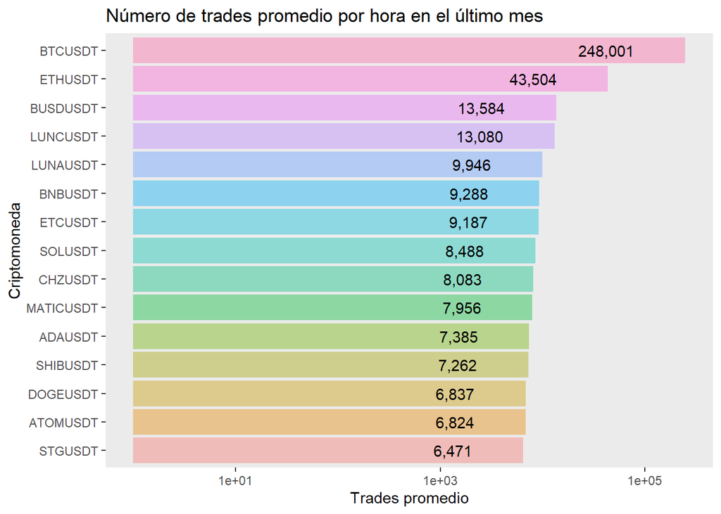

```r
df$symbols <- factor(df$symbols, levels = df$symbols[order(df$Mean_trades, decreasing = FALSE)])

df[0:15,] %>%
  ggplot(aes(x = Mean_trades, y= symbols, fill = symbols)) +
  geom_bar(stat = "Identity",
           position = 'dodge',
           alpha = 0.4) +
  #theme_minimal() +
  theme(panel.grid.major = element_blank(),
        panel.grid.minor = element_blank(),
        legend.position = "none") +
  labs(title = "Número de trades promedio por hora en el último mes",
       y = "Criptomoneda",
       x = "Trades promedio") +
  scale_x_log10() +
  geom_text(aes(label = comma(Mean_trades)), hjust = 1, nudge_x = -.5, colour = "black")
```

### 3.4.- Análisis técnico y selección de las mejores criptomonedas.

Ya que se obtuvieron las mejores 15 criptomonedas, basado en el promedio de transacciones hechas en los últimos 28 días, fue necesario ponerlas a prueba. Utilizando la librería `TTR`, se aplicaron tres estrategias a las criptomonedas para determinar cual de las 3 ha sido la mas exacta al momento de estimar el comportamiento del mercado y asi elegir las criptomonedas que han tenido mejor comportamiento, basándose en su tendencia, oscilación y volatilidad por lo que las tres estrategias o indicaciones a utilizar son:

1. Indicador de tendencia: Media Móvil de Convergencia/Divergencia (MACD), el cual es un indicador de impulso de seguimiento de tendencias que muestra la relación entre dos promedios móviles del precio de un valor. El MACD se calcula restando la media móvil exponencial (EMA) de 26 períodos de la EMA de 12 períodos. El resultado de ese cálculo es la línea MACD. Luego, se traza una EMA de nueve días del MACD llamada “línea de señal” en la parte superior de la línea MACD, que puede funcionar como un desencadenante de señales de compra y venta. Los comerciantes pueden comprar el valor cuando el MACD cruza por encima de su línea de señal y vender, o vender en corto, el valor cuando el MACD cruza por debajo de la línea de señal.
- 2. Indicador de oscilación: Índice de fuerza relativa (RSI), el cual es un indicador de impulso utilizado en el análisis técnico que mide la magnitud de los cambios de precios recientes para evaluar las condiciones de sobrecompra o sobreventa en el precio de una acción u otro activo. El RSI puede tener una lectura de 0 a 100. La interpretación y el uso tradicionales del RSI son que los valores de 70 o más indican que un valor se está sobrecomprando o sobrevaluando y puede estar preparado para una inversión de tendencia o un retroceso correctivo en el precio. Una lectura de RSI de 30 o menos indica una condición de sobreventa o infravaloración.
- 3. Indicador de volatilidad: Bandas de Bollinger (BB), las cuales son un indicador gráfico utilizado en el análisis técnico para establecer un rango de precios de un activo. Para conseguir los parámetros de las bandas de bollinger usamos dos medidas estadísticas: la media móvil y la desviación típica. Se generan tres lineas, la central es la media móvil del precio de cotización del activo en las últimas 20 sesiones (por defecto). A partir de ahí, la banda superior se extrae de calcular la desviación típica con valor 2 (por defecto) y añadirlo al valor medio móvil. En cuanto a la banda inferior, se extrae de calcular la desviación estándar con valor 2 (por defecto) restada al valor de la media móvil. Entre la banda superior y la banda inferior del gráfico se crea un rango de cotización del valor que se esté estudiando que puede servir de varias formas. Por un lado, la teoría de las bandas de bollinger explica que el 90% de las variaciones de este precio tendrán lugar en esa franja, por lo que los movimientos que tengan lugar fuera pueden ser importantes. Otro uso de este indicador es la interpretación de las bandas de bollinger como medidor de la volatilidad del valor dependiendo de la separación de las bandas superior e inferior. Si vemos un estrechamiento entre las bandas, el valor estará sufriendo menos volatilidad, mientras que si se distancian, será un momento de más volatilidad.

También fue usada la librería `quantmod` para graficar la información.

```r
bestsymb[,1] -> best15
```

```r
#define the interval and the limit
interval <- "1h"
limit <- 672

list_names_candles= list()

#create a data frame for each crypto selected with its candles information
for (b in best15)
{
bestcandles <- binance_klines(symbol = b,
               interval = interval,
               limit = limit,
               start_time = '2022-08-15')

assign(paste('X', b, sep=''),bestcandles)
list_names_candles <- append(list_names_candles, paste('X', b, sep=''))
}
```

```r
library(TTR)
library(quantmod)
df_list = mget(ls(pattern = "X[A-Z]"))
```

Se utilizó la librería `xts` para dar una estructura de serie de tiempo a las tablas consistente de las columnas `open`, `high`, `low` y `close` y se guardó nuevas bases de datos en los objetos con terminación `.xts`.

```r
for(x in list_names_candles){
df_aux <- get(x)
  df_aux%>%
    select(open, high, low, close) %>%
    xts(order.by = df_aux$open_time) -> b
  assign(paste(x, ".xts", sep=''),b)
}
```

Se utilizó la librería `quantmod` para realizar la gráfica de velas con los valores en objetos xts.

Se obtuvieron los valores de las estrategias MACD, RSI y BBANDS en BTCUSDT, sin embargo, para un correcto análisis es mejor observarlos gráficamente.

```r
macd3 <- MACD(Cl(XBTCUSDT.xts), nFast=12, nSlow=26,
             nSig=9, percent=FALSE)
tail(macd3,n=5)
```

```
##                         macd   signal
## 2022-09-11 19:00:00 86.47717 71.11545
## 2022-09-11 20:00:00 76.11487 72.11534
## 2022-09-11 21:00:00 71.78115 72.04850
## 2022-09-11 22:00:00 73.18373 72.27555
## 2022-09-11 23:00:00 76.10502 73.04144
```

```r
rsi3 <- RSI(Cl(XBTCUSDT.xts), n = 14, maType = "EMA")
tail(rsi3,n=5)
```

```
##                          rsi
## 2022-09-11 19:00:00 53.61093
## 2022-09-11 20:00:00 48.46530
## 2022-09-11 21:00:00 51.28324
## 2022-09-11 22:00:00 54.73099
## 2022-09-11 23:00:00 56.41451
```

```r
bbands3 <- BBands(Cl(XBTCUSDT.xts), n=20, maType = "SMA", sd = 2)
```

A continuación se muestran gráficamente las 15 criptomonedas elegidas, a partir de su cantidad de trades promedio, en conjunto a las estrategias mencionadas anteriormente.

```r
#create the list of the ".xts" objects
xts_list <- mget(ls(pattern = "[A-Z].xts$"))

#create a list of the names, without the "X" start and ".xts" ending, to title the charts
names(xts_list) %>%
  str_remove(.,".xts") %>%
  substr(., 2, nchar(xts_list)) -> xts_names
```

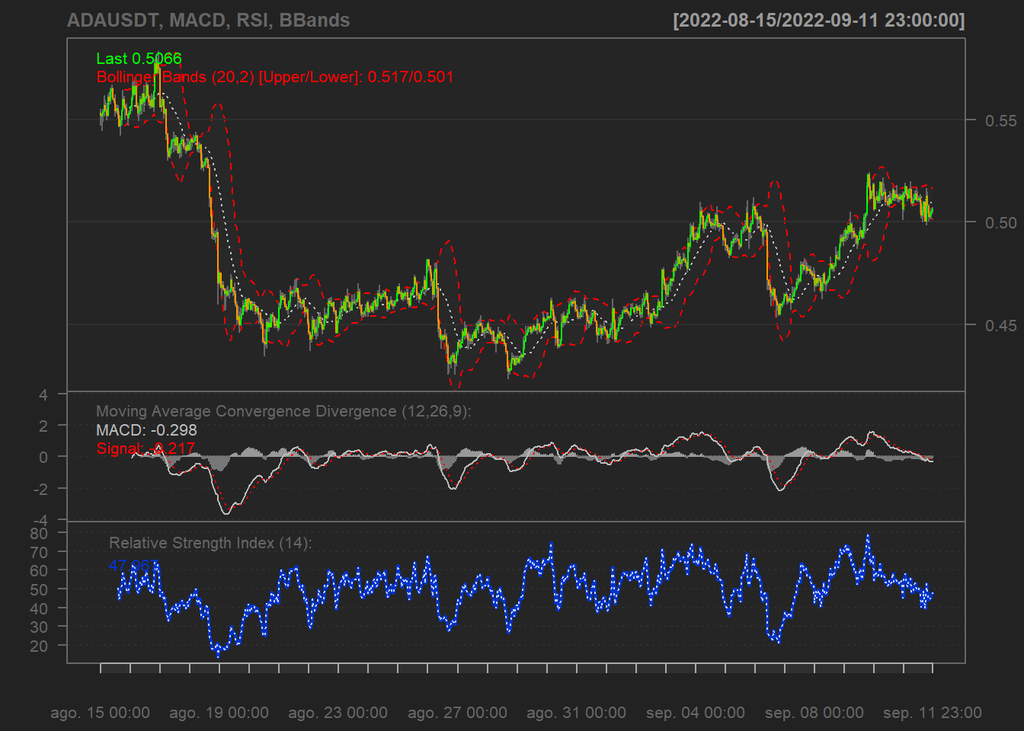

```
## [1] "Precios dados desde las 00:00 del 15 de agosto hasta las 23:00 del 11 de septiembre. Precios en dólares."
```

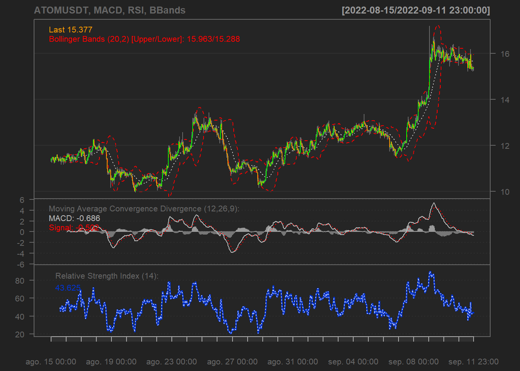

```
## [1] "Precios dados desde las 00:00 del 15 de agosto hasta las 23:00 del 11 de septiembre. Precios en dólares."
```

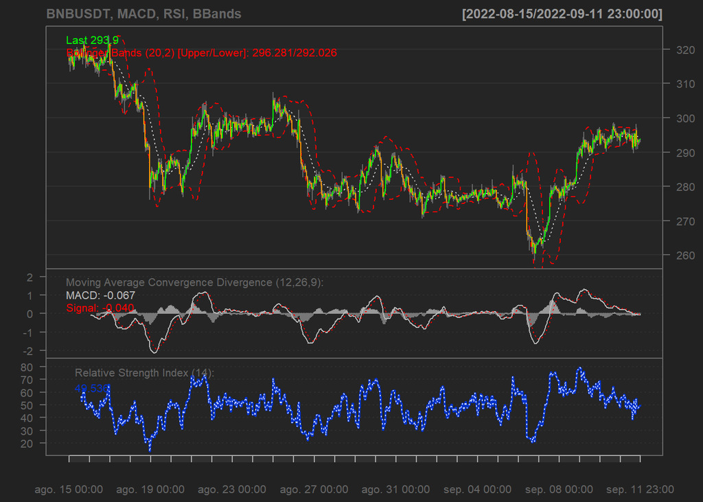

```
## [1] "Precios dados desde las 00:00 del 15 de agosto hasta las 23:00 del 11 de septiembre. Precios en dólares."
```

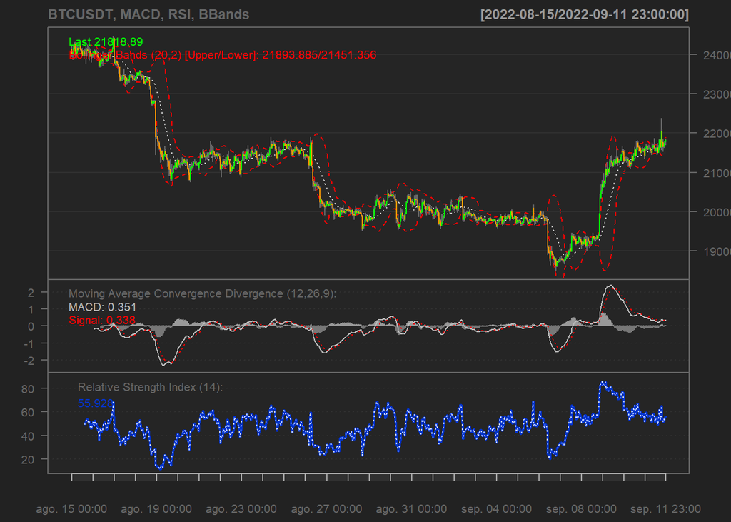

```
## [1] "Precios dados desde las 00:00 del 15 de agosto hasta las 23:00 del 11 de septiembre. Precios en dólares."
```

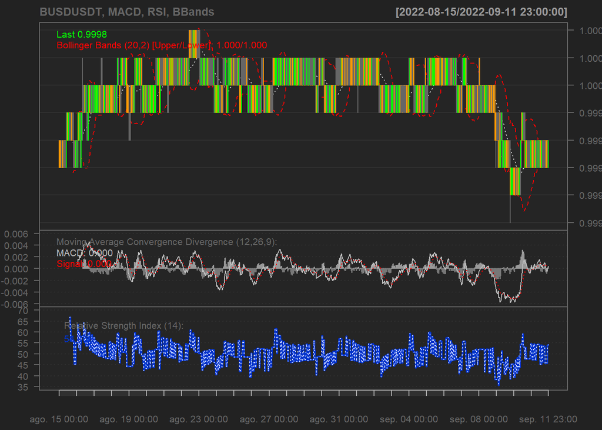

```
## [1] "Precios dados desde las 00:00 del 15 de agosto hasta las 23:00 del 11 de septiembre. Precios en dólares."
```

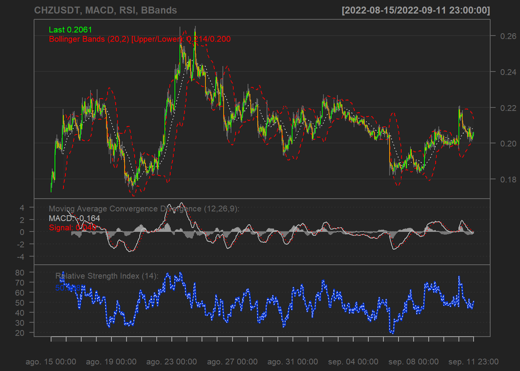

```
## [1] "Precios dados desde las 00:00 del 15 de agosto hasta las 23:00 del 11 de septiembre. Precios en dólares."
```

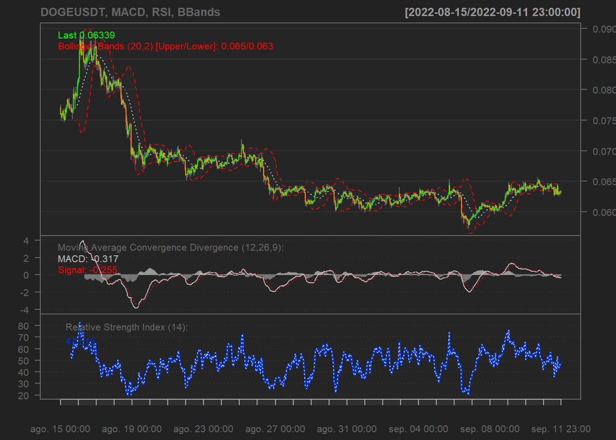

```
## [1] "Precios dados desde las 00:00 del 15 de agosto hasta las 23:00 del 11 de septiembre. Precios en dólares."
```

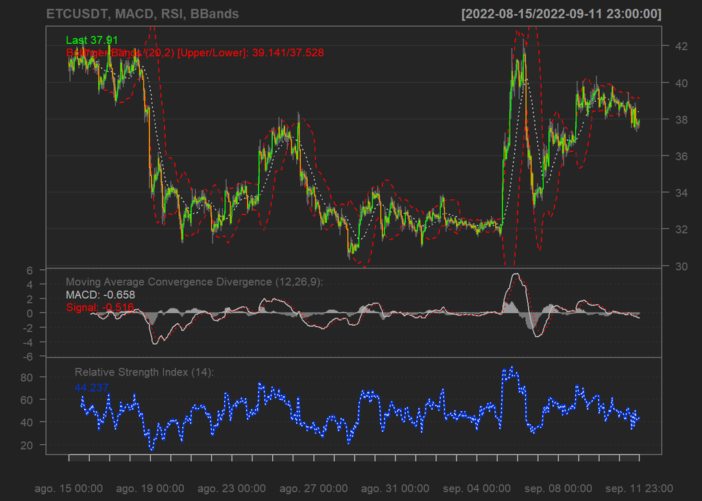

```
## [1] "Precios dados desde las 00:00 del 15 de agosto hasta las 23:00 del 11 de septiembre. Precios en dólares."
```

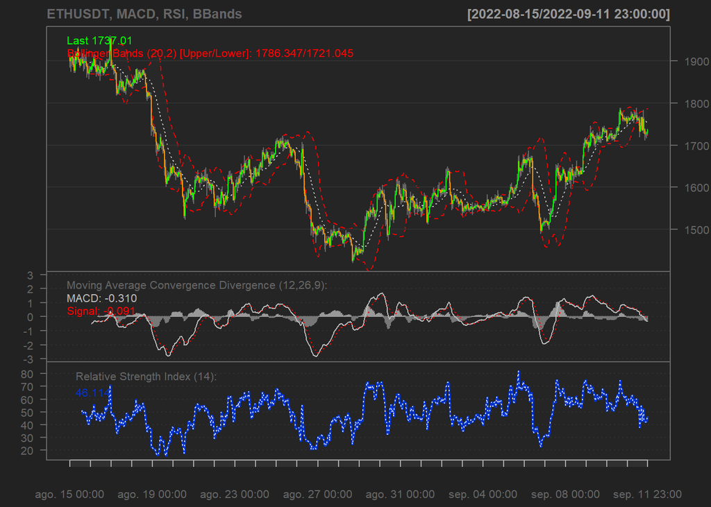

```
## [1] "Precios dados desde las 00:00 del 15 de agosto hasta las 23:00 del 11 de septiembre. Precios en dólares."
```

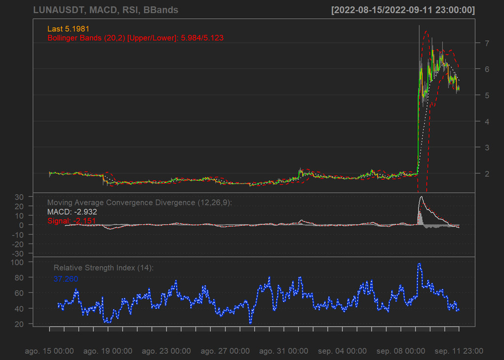

```
## [1] "Precios dados desde las 00:00 del 15 de agosto hasta las 23:00 del 11 de septiembre. Precios en dólares."
```

[figure not shown]

```
## [1] "Precios dados desde las 00:00 del 15 de agosto hasta las 23:00 del 11 de septiembre. Precios en dólares."
```

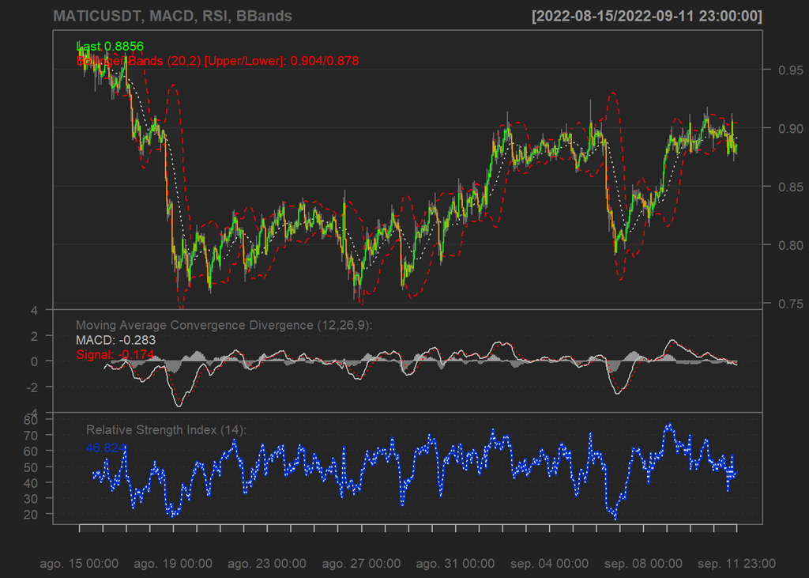

```
## [1] "Precios dados desde las 00:00 del 15 de agosto hasta las 23:00 del 11 de septiembre. Precios en dólares."
```

[3 more figures not shown]

```
## [1] "Precios dados desde las 00:00 del 15 de agosto hasta las 23:00 del 11 de septiembre. Precios en dólares."
```

```r
#start a counter to access each element of the lists
i <-1

#create the charts of the 15 cryptos with the strategies
for (x in xts_list) {
chartSeries(x,
            subset=NULL,
            name = paste(xts_names[i], ", MACD, RSI, BBands", sep=''),
TA = c(addMACD(fast=12,slow=26,signal=9,type="EMA"),
       addRSI(n=14, maType = "EMA", wilder = TRUE),
       addBBands(n=20, maType = "SMA", sd = 2)))
i <- i+1
print("Precios dados desde las 00:00 del 15 de agosto hasta las 23:00 del 11 de septiembre. Precios en dólares.")
}
```

### 3.5.- Evaluación para la elección de criptomonedas y estrategia para uso en el programa.

Se evaluarán las estrategias simulando su uso. Vamos a considerar velas de 1 hora para identificar patrones de compra y velas de 1 minuto durante bloques de 30 minutos para evaluar el desempeño de la estrategia. Se decidió utilizar velas de un minuto para dar un seguimiento de “tiempo real” al momento de evaluar cada compra.

#### 3.5.1 Funciones compra_evaluacion

Estas funciones toman como entrada la información de las velas de las criptomonedas, genera la respectiva estrategia (MACD, RSI y BB) e identifica las señales de compra. Genera un data frame con esta información.

Args: data_xts: Data frame tipo serie de tiempo con la información necesaria de las velitas para obtener las señales de la estrategia.

Return: comprar: Es un data frame con la información de las señales de compra para la criptomoneda utilizando la respectiva estrategia.

```r
#Vamos a crear una función que guarde las señales de compra mediante MACD
MACD_compra_evaluacion <- function(data_xts){
  macd_data <- MACD(Cl(data_xts), nFast=12, nSlow=26, nSig=9, percent=FALSE)
  comprar <- list()
  cantidad_renglones <- nrow(data_xts)

  # Guardamos las señales de compra del MACD en una lista llamada "comprar".
  for (j in 1:34){
    comprar<- append(comprar, FALSE)
  }
  for(i in 35:cantidad_renglones){
    if ((macd_data$macd[i] > 0) && (macd_data$macd[i-1] < 0) && (macd_data$macd[i] >= macd_data$signal[i]))  {
         comprar <- append(comprar, TRUE)
    } else{
      comprar <- append(comprar, FALSE)
    }
  }
  return(comprar)
}
```

```r
#Vamos a crear una función que guarde las señales de compra mediante RSI
RSI_compra_evaluacion <- function(data_xts){
  rsi_data <- RSI(Cl(data_xts), n = 14, maType = "EMA")
  comprar <- list()
  cantidad_renglones <- nrow(data_xts)
  # Guardamos las señales de compra del RSI en una lista llamada "comprar".
  for (i in 1:15){

    comprar<- append(comprar, FALSE)
  }
  for(i in 16:cantidad_renglones){
    if ((rsi_data$rsi[i-1]>30) && (rsi_data$rsi[i]<30)) {
        comprar <- append(comprar, TRUE)
      } else {
        comprar <- append(comprar, FALSE)
      }
  }
  return(comprar)
}
```

```r
#Vamos a crear una función que guarde las señales de compra mediante Bandas de Bollinger
BB_compra_evaluacion <- function(data_xts){
  bb_data <- BBands(Cl(data_xts), n=20, maType = "SMA", sd = 2)
  comprar <- list()
  cantidad_renglones <- nrow(data_xts)
  # Guardamos las señales de compra de BB en una lista llamada "comprar".
  # Bollinger Bands - Señal de compra: Cuando el precio, estando por debajo, penetra al promedio móvil y enseguida toca la banda superior.
  for (i in 1:21){

    comprar<- append(comprar, FALSE)
  }
  for(i in 22:cantidad_renglones){
    if (bb_data$pctB[i]>1) {
        comprar <- append(comprar, TRUE)
      } else {
        comprar <- append(comprar, FALSE)
      }
  }
  return(comprar)
}
```

#### 3.5.2 Criterio de venta y la función de velas por minuto.

**velas_por_minuto** Esta función obtiene las velas de 1 minuto, durante un periodo de 30 minutos para evaluar el desempeño de una criptomoneda desde su compra hasta su respectiva venta. De esta manera, buscamos obtener la diferencia porcentual de dichos precios para cuantificar la ganancia (o en su defecto, pérdida) Args: tiempo_inicio: Representa el tiempo de inicio del bloque de velas a descargar.

```
crypto: Símbolo de la criptomoneda a evaluar.
```

Return: candles: Es un data frame con la información descargada desde Binance.

```r
#Esta es una función que genera 30 velas en intervalos de 1 minuto.
velas_por_minuto <- function(tiempo_inicio, crypto){
  intervalo <- "1m"
  limit <- 30
  start_time <- tiempo_inicio
  candles <- binance_klines(symbol = crypto,
             interval = intervalo,
             limit = limit,
             start_time = start_time)
  return(candles)
}

######################################################################
#prueba1 <- velas_por_minuto( "2022-08-15 00:59:59", "BTCUSDT")
```

**precio_venta** Esta función da seguimiento a tiempo pseudo-real (información de las criptomonedas por minuto), para distinguir señales de venta de acuerdo al criterio del 2%. Criterio del 2%: Creamos un límite inferior para asegurar que no perderemos una cantidad mayor al 2% del precio de cierre de la compra. Este precio se irá actualizando de acuerdo a los nuevos valores de cierre de velas cuyo valor haya aumentado.

Args: precio_compra: Representa el precio en el que se realizó la compra.

```
velas_minutos: Bloque de 30 velas por minuto sobre el cual se aplicará la estrategia de venta.
```

Return: precio_venta_eval: Esta función regresa el precio de cierre de la venta identificada.

```r
# Esta función utiliza el criterio de venta del 2% para determinar el precio de venta de la cripto despues de una compra.
precio_venta <- function(precio_compra, velas_minutos){
  precio_aux <- precio_compra
  for (i in 1:30) {
    if(velas_minutos$low[i] < (0.98*precio_aux)){
      precio_aux <- velas_minutos$close[i]
      return(precio_aux)
    } else {
        precio_aux <- velas_minutos$close[i]
        }
  }
  return(precio_aux)
}

######################################################################
#precio_venta(23950.97, prueba1)
```

#### 3.5.3 Evaluación de las estrategias y las criptomonedas

Para la evaluación de las estrategias, se creó un dataframe que plasma el precio de apertura y de cierre de los períodos establecidos, para las 15 criptomonedas definidas anteriormente. Se crea una columna que registra el estatus de compraventa; en caso de que se registre una venta, se calcula la diferencia de ambos precios para obtener la perdida o ganancia. Esta función se genero para las tres estrategias, comenzado con MACD, RI y por último Bandas de Bollinger.

```r
evaluacion_ganancia_porcentual <- data.frame(
  "Criptomoneda"= xts_names)
for (i in 1:15) {
  # Creamos un data frame auxiliar en donde vamos a guardar las señales de compra de cada criptomoneda:
  velas_aux<- xts_list[[i]]
  velas_aux
  macd_aux <- MACD_compra_evaluacion(velas_aux)
  # Guardamos esta información de las señales de compra en el data frame de cada criptomoneda:

  macd_aux %>%
  as.data.frame() %>%
    t() -> macd_aux

  df_list[[i]]$compra_MACD <- macd_aux

  # Obtenemos la información que requerimos para utilizar las funciones (los argumentos)

  df_aux<- df_list[[i]]
  indices_compra_aux <- which(df_aux$compra_MACD == TRUE)
  precio_cierre_compra_aux <- df_aux[compra_MACD == TRUE]$close
  tiempo_cierre_compra_aux <- df_aux[compra_MACD == TRUE]$close_time
  simbolo_cripto_aux <- xts_names[[i]]

  precios_ventas_crypto <- c()

  for (j in 1:length(indices_compra_aux)) {
    #Obtenemos las 30 velas que dan un seguimiento a tiempo pseudo-real
    velas_minuto_aux <- velas_por_minuto(tiempo_cierre_compra_aux[[j]], simbolo_cripto_aux)
    #Obtenemos los precios de venta de las criptomonedas de acuerdo a la estrategia de venta.
    precio_venta_aux <- precio_venta(precio_cierre_compra_aux[[j]], velas_minuto_aux)
    precios_ventas_crypto <- append(precios_ventas_crypto, precio_venta_aux)
  }
  a=(precios_ventas_crypto - precio_cierre_compra_aux)*100/precio_cierre_compra_aux
  a <- sum(a)
  evaluacion_ganancia_porcentual$MACD[i] <- a
}
```

```r
for (i in 1:15) {
  # Creamos un data frame auxiliar en donde vamos a guardar las señales de compra de cada criptomoneda:
  velas_aux<- xts_list[[i]]
  rsi_aux <- RSI_compra_evaluacion(velas_aux)
  # Guardamos esta información de las señales de compra en el data frame de cada criptomoneda:

  rsi_aux %>%
  as.data.frame() %>%
    t() -> rsi_aux

  df_list[[i]]$compra_RSI <- rsi_aux

  # Obtenemos la información que requerimos para utilizar las funciones (los argumentos)

  df_aux<- df_list[[i]]
  indices_compra_aux <- which(df_aux$compra_RSI == TRUE)
  precio_cierre_compra_aux <- df_aux[compra_RSI == TRUE]$close
  tiempo_cierre_compra_aux <- df_aux[compra_RSI == TRUE]$close_time
  simbolo_cripto_aux <- xts_names[[i]]

  precios_ventas_crypto_RSI <- c()

  for (j in 1:length(indices_compra_aux)) {
    #Obtenemos las 30 velas que dan un seguimiento a tiempo pseudo-real
    velas_minuto_aux <- velas_por_minuto(tiempo_cierre_compra_aux[[j]], simbolo_cripto_aux)
    #Obtenemos los precios de venta de las criptomonedas de acuerdo a la estrategia de venta.
    precio_venta_aux <- precio_venta(precio_cierre_compra_aux[[j]], velas_minuto_aux)
    precios_ventas_crypto_RSI <- append(precios_ventas_crypto_RSI, precio_venta_aux)
  }
  a=(precios_ventas_crypto_RSI - precio_cierre_compra_aux)*100/precio_cierre_compra_aux
  a <- sum(a)
  evaluacion_ganancia_porcentual$RSI[i] <- a
}
```

```r
for (i in 1:15) {
  # Creamos un data frame auxiliar en donde vamos a guardar las señales de compra de cada criptomoneda:
  velas_aux<- xts_list[[i]]
  bb_aux <- BB_compra_evaluacion(velas_aux)
  # Guardamos esta información de las señales de compra en el data frame de cada criptomoneda:

  bb_aux %>%
  as.data.frame() %>%
    t() -> bb_aux

  df_list[[i]]$compra_BB <- bb_aux

  # Obtenemos la información que requerimos para utilizar las funciones (los argumentos)

  df_aux<- df_list[[i]]
  indices_compra_aux <- which(df_aux$compra_BB == TRUE)
  precio_cierre_compra_aux <- df_aux[compra_BB == TRUE]$close
  tiempo_cierre_compra_aux <- df_aux[compra_BB == TRUE]$close_time
  simbolo_cripto_aux <- xts_names[[i]]

  precios_ventas_crypto_BB <- c()

  for (j in 1:length(indices_compra_aux)) {
    #Obtenemos las 30 velas que dan un seguimiento a tiempo pseudo-real
    velas_minuto_aux <- velas_por_minuto(tiempo_cierre_compra_aux[[j]], simbolo_cripto_aux)
    #Obtenemos los precios de venta de las criptomonedas de acuerdo a la estrategia de venta.
    precio_venta_aux <- precio_venta(precio_cierre_compra_aux[[j]], velas_minuto_aux)
    precios_ventas_crypto_BB <- append(precios_ventas_crypto_BB, precio_venta_aux)
  }
  a=(precios_ventas_crypto_BB - precio_cierre_compra_aux)*100/precio_cierre_compra_aux
  a <- sum(a)
  evaluacion_ganancia_porcentual$BB[i] <- a
}
```

#### 3.5.4 Resultados de la evaluación

Con la información obtenida en los dataframes, se obtuvó la sumatoria porcentual de las pérdidas y ganancia para cada una de las estrategias; con los resultados obtenidos, podemos observar que MACD muestra el mejor resultado porcentual, por lo que se elige esta estrategia como la base del programa.

```r
#Evaluación de las estrategias
#Evaluación de las estrategias

sum(evaluacion_ganancia_porcentual$MACD)
sum(evaluacion_ganancia_porcentual$RSI)
sum(evaluacion_ganancia_porcentual$BB)
```

[output not shown]

#### 3.5.5.- Resultados promedio de las criptomonedas al utilizar la estrategia MACD

Una vez seleccionada la estrategia MACD, se evalúan las 15 criptomonedas bajo este método para obtener los 3 mejores resultados, siendo BNB, STG Y ATOM las criptomonedas con los mejores resultados en cuanto a ganancia.

```r
for(i in 1:15){
  print(evaluacion_ganancia_porcentual$MACD[[i]])
}
```

```
## [1] 1.579335
## [1] 2.731492
## [1] 5.364075
## [1] 0.3944865
## [1] -0.12
## [1] -4.084445
## [1] -3.58131
## [1] -0.8520347
## [1] 1.871096
## [1] -2.51336
## [1] -7.456693
## [1] -1.88531
## [1] -2.333974
## [1] 1.04072
## [1] 3.32334
```

Análisis visual del desempeño de las tres estrategias seleccionadas:

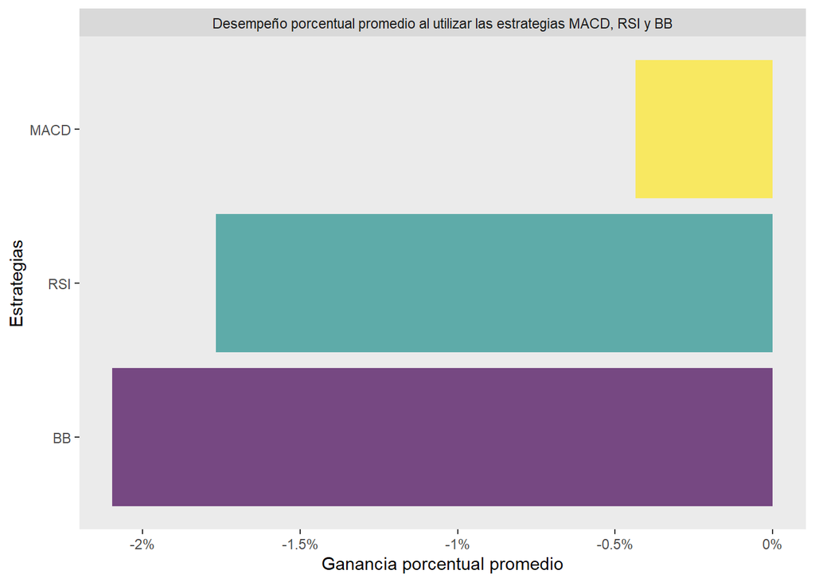

```r
#grafica2_df$MACD <- mean(evaluacion_ganancia_porcentual$MACD)

#<- factor(df$symbols, levels = df$symbols[order(df$Mean_trades, decreasing = FALSE)])
m_1 <- mean(evaluacion_ganancia_porcentual$MACD)
m_2 <- mean(evaluacion_ganancia_porcentual$RSI)
m_3 <- mean(evaluacion_ganancia_porcentual$BB)
grafica2_df <-data.frame(
  "Estrategia"=c("MACD", "RSI", "BB"),
  "Promedio"= c(m_1, m_2, m_3))

grafica2_df$Estrategia <- factor(grafica2_df$Estrategia, levels = grafica2_df$Estrategia[order(grafica2_df$Promedio, decreasing = FALSE)])

grafica2_df %>%
#Evaluación de las estrategias
ggplot(aes(x = Estrategia, fill=Estrategia, y= Promedio)) +
  geom_bar(stat = "Identity",
           position = 'dodge',
           alpha = 0.7) +
  theme(panel.grid.major = element_blank(),
        panel.grid.minor = element_blank(),
        legend.position = "none") +
  scale_fill_viridis(discrete = TRUE, direction = 1)+
  scale_y_continuous(labels = function(x) paste0(x, "%"))+
  coord_flip() +
  facet_wrap(~"Desempeño porcentual promedio al utilizar las estrategias MACD, RSI y BB")   +
  labs(y = "Ganancia porcentual promedio",
       x = "Estrategias")
```

```r
  geom_text(aes(label = comma(Promedio)), hjust = 1, nudge_x = -.5, colour = "black")
```

```
## mapping: label = ~comma(Promedio)
## geom_text: parse = FALSE, check_overlap = FALSE, na.rm = FALSE
## stat_identity: na.rm = FALSE
## position_nudge
```

Análisis visual del desempeño de las criptomonedas bajo la estrategia previamente seleccionada (MACD):

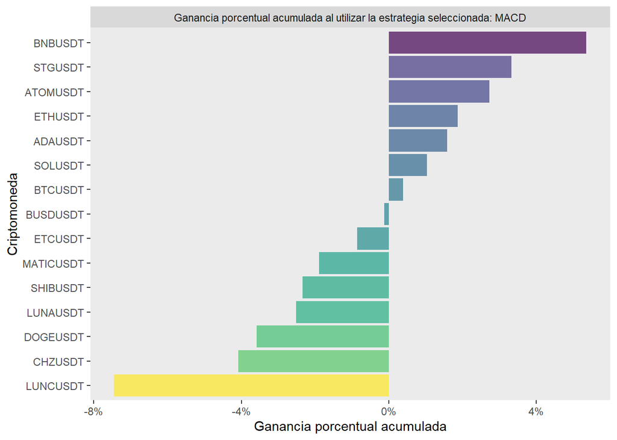

```r
grafica3_df<- evaluacion_ganancia_porcentual

grafica3_df$Criptomoneda <- factor(grafica3_df$Criptomoneda, levels = grafica3_df$Criptomoneda[order(grafica3_df$MACD, decreasing = FALSE)])

grafica3_df %>%
#Evaluación de las estrategias
ggplot(aes(x = Criptomoneda, fill=MACD, y= MACD)) +
  geom_bar(stat = "Identity",
           position = "dodge",
           alpha = 0.7) +
  theme(panel.grid.major = element_blank(),
        panel.grid.minor = element_blank(),
        legend.position = "none") +
  scale_fill_viridis(discrete = FALSE, direction = -1)+
  scale_y_continuous(labels = function(x) paste0(x, "%")) +
  coord_flip() +
  facet_wrap(~"Ganancia porcentual acumulada al utilizar la estrategia seleccionada: MACD")   +
  labs(y = "Ganancia porcentual acumulada",
       x = "Criptomoneda")
```

```r
  geom_text(aes(label = comma(Promedio)), hjust = 1, nudge_x = -.5, colour = "black")
```

```
## mapping: label = ~comma(Promedio)
## geom_text: parse = FALSE, check_overlap = FALSE, na.rm = FALSE
## stat_identity: na.rm = FALSE
## position_nudge
```

## 4.- Desarrollo

### 4.1.- Estructura del programa.

Cuando sucede una compra, se envía una alerta a telegram y se registran las operaciones haciendo el cálculo de la ganancia.

El script se pausa por 60 segundos para despues seguir funcionando.

- Se incluye una opción para poder detener el bot desde el chat y un mensaje de bienvenida cuando se comienza a correr el script.
- Al final se cierra el script, lo que significa que todo lo anterior se va a estar repitiendo de forma automática para mandar señales constantemente.

### 4.2.- Script

```
## #!/usr/bin/Rscript
##
## # Proyecto R
##
##
## library(binancer)
## library(kableExtra)
## library(magrittr)
## library(dplyr)
## library(xts)
## library(dygraphs)
## library(TTR)
## library(telegram.bot)
## library(ggplot2)
## library(quantmod)
##
## key_1 <- "UBaFx31DvB7FwWnR65te9Nhx8ZduX4oNEtiP8GTLVMmM4TCsMUQRGz6TShwToUt8"
## secret_1 <- "0DleR5sMIlbYzk99q3GV0N07OBk4iESgJNrrdiOR8ZWJwK6ywg8xZtSZhmtQNhqH"
##
##
## binance_credentials(key = key_1, secret = secret_1)
##
## symbols <- c("BNBUSDT", "STGUSDT", "ATOMUSDT")
## sub_symbols <- c("BNB", "STG", "ATOM")
## increase <- 0.05 #Aumento de 5%
## run <- TRUE
##
## interval <- "1h"
## limit <- 100 #100 horas
##
## ## MACD
## nFast <- 12
## nSlow <- 26
## nSig <- 9
##
## ## RSI
## n_rsi <- 14
##
## #Uso de Telegram Bot
## token <- "5714075349:AAER6IE28EsAFPAeqroEWcwgTy38RxTu5Pw"
```

[output cut: 167 more lines]

[output not shown]

### 4.2.- Automatización en AWS

El R script que contiene el código de programación, `ProyectoR_DEM.r`, se cargó a Amazon Web Services (AWS) el cual es una colección de servicios de computación en la nube pública que en conjunto forman una plataforma de computación en la nube, ofrecidas a través de Internet por Amazon.com, con la finalidad de que el programa se ejecute de forma automática sin inconvenientes.

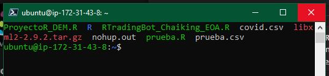

AWS

### 4.3.- Visualizacion en Telegram

Mensajes recibidos al momento de iniciar, comprar, vender y cerrar el trade.

[figure not shown]

AWS

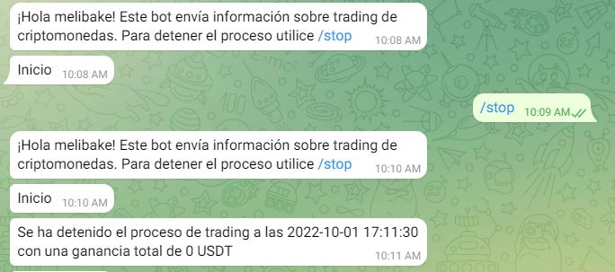